# Introduction

In the single cell World, which includes flow cytometry, mass cytometry, single-cell RNA-seq (scRNA-seq), and others, there is a need to improve data visualisation and to bring analysis capabilities to researchers even from non-technical backgrounds. *scDataviz* [@scDataviz] attempts to fit into this space, while also catering for advanced users. Additonally, due to the way that *scDataviz* is designed, which is based on *SingleCellExperiment* [@Lun], it has a 'plug and play' feel, and immediately lends itself as flexibile and compatibile with studies that go beyond *scDataviz*. Finally, the graphics in *scDataviz* are generated via the *ggplot* [@Wickham] engine, which means that users can 'add on' features to these with ease.

# Installation

## 1. Download the package from Bioconductor

```r
    if (!requireNamespace('BiocManager', quietly = TRUE))
        install.packages('BiocManager')

    BiocManager::install('scDataviz')
```

Note: to install development version:

```r
    devtools::install_github('kevinblighe/scDataviz')
```

## 2. Load the package into R session

```r
  library(scDataviz)
```

# Tutorial 1: CyTOF FCS data

Here, we will utilise some of the flow cytometry data from [Deep phenotyping detects a pathological CD4+ T-cell complosome signature in systemic sclerosis](https://www.nature.com/articles/s41423-019-0360-8).

In a practical situation, we would normally read in the data from the raw FCS files and then QC filter, normalise, and transform them. This can be achieved via the `processFCS` function, which, by default, also removes variables based on low variance and downsamples [randomly] your data to 100000 variables. The user can change these via the `downsample` and `downsampleVar` parameters. An example (*not run*) is given below:

```r
  filelist <- list.files(
    path = "scDataviz_data/FCS/",
    pattern = "*.fcs|*.FCS",
    full.names = TRUE)
  filelist

  metadata <- data.frame(
    sample = gsub('\\ [A-Za-z0-9]*\\.fcs$', '',
      gsub('scDataviz_data\\/FCS\\/\\/', '', filelist)),
    group = c(rep('Healthy', 7), rep('Disease', 11)),
    treatment = gsub('\\.fcs$', '',
      gsub('scDataviz_data\\/FCS\\/\\/[A-Z0-9]*\\ ', '', filelist)),
    row.names = filelist,
    stringsAsFactors = FALSE)
  metadata

  sce <- processFCS(
    files = filelist,
    metadata = metadata,
    transformation = TRUE,
    transFun = function (x) asinh(x),
    asinhFactor = 5,
    downsample = 9000,
    downsampleVar = 0.2,
    newColnames = paste0('CD', 1:65))
```

For this vignette, due to the fact that the raw FCS data is > 500 megabytes, we will work with a smaller pre-prepared dataset that has been downsampled to 9000 cells using the above code.

Load the pre-prepared complosome data.

```r
  load(system.file('extdata/', 'complosome.rdata', package = 'scDataviz'))
```

To see a full vignette that utilises the raw FCS files, see the [GitHub vignette](https://github.com/kevinblighe/scDataviz/).

One can also create a new *SingleCellExperiment* object manually using any type of data, including any data from scRNA-seq produced elsewhere. Import functions for data deriving from other sources is covered in Tutorials 2 and 3 in this vignette. All functions in *scDataviz* additionally accept data-frames or matrices on their own, de-necessitating the reliance on the *SingleCellExperiment* class.

## Perform principal component analysis (PCA)

We can use the *PCAtools* [@PCAtools] package for the purpose of performing PCA.

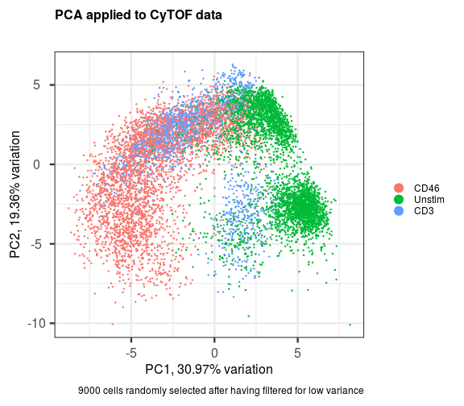

```r
  library(PCAtools)
  p <- pca(assay(sce, 'scaled'), metadata = metadata(sce))
  biplot(p,
    lab = NULL,
    pointSize = 0.5,
    colby = 'treatment',
    legendPosition = 'right',
    title = 'PCA applied to CyTOF data',
    caption = '9000 cells randomly selected after having filtered for low variance')
```

We can add the rotated component loadings as a new reduced dimensional component to our dataset. Let's just add the first 20 PCs.

```r
  reducedDim(sce, 'PCA') <- p$rotated[,1:20]
```

For more functionality via *PCAtools*, check the vignette: [PCAtools: everything Principal Component Analysis](https://bioconductor.org/packages/release/bioc/vignettes/PCAtools/inst/doc/PCAtools.html)

## Perform UMAP

UMAP can be performed on the entire dataset, if your computer's memory will permit. Currently it's default is to use the data contained in the 'scaled' assay component of your *SingleCellExperiment* object.

```r
  sce <- performUMAP(sce)
```

UMAP can also be stratified based on a column in your metadata, e.g., (treated versus untreated samples); however, to do this, I recommend creating separate *SingleCellExperiment* objects from the very start, i.e., from the the data input stage, and processing the data separately for each group.

We can also perform UMAP on a select number of PC eigenvectors. *PCAtools* [@PCAtools] can be used to infer ideal number of dimensions to use via the elbow method and Horn's parallel analysis.

```r
  elbow <- findElbowPoint(p$variance)
  horn <- parallelPCA(assay(sce, 'scaled'))

  elbow
```

```
## PC9
##   9
```

```r
  horn$n
```

```
## [1] 4
```

Let's use the number of PCs identified by Horn's.

```r
  sce <- performUMAP(sce, reducedDim = 'PCA', dims = c(1:horn$n))
```

## Create a contour plot of the UMAP layout

This and the remaining sections in this tutorial are about producing great visualisations of the data and attempting to make sense of it, while not fully overlapping with functionalioty provided by other programs that operate in tis space.

With the contour plot, we are essentially looking at celluar density. It can provide for a beautiful viusualisation in a manuscript while also serving as a useful QC tool: if the density is 'scrunched up' into a single area in the plot space, then there are likely issues with your input data distribution. We want to see well-separated, high density 'islands', or, at least, gradual gradients that blend into one another across high density 'peaks'.

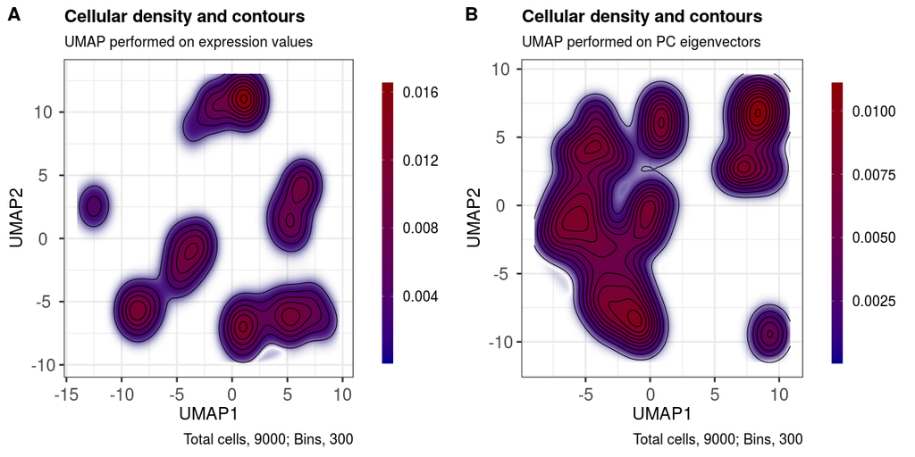

```r
  ggout1 <- contourPlot(sce,
    reducedDim = 'UMAP',
    subtitle = 'UMAP performed on expression values',
    legendLabSize = 18,
    axisLabSize = 22,
    titleLabSize = 22,
    subtitleLabSize = 18,
    captionLabSize = 18)

  ggout2 <- contourPlot(sce,
    reducedDim = 'UMAP_PCA',
    subtitle = 'UMAP performed on PC eigenvectors',
    legendLabSize = 18,
    axisLabSize = 22,
    titleLabSize = 22,
    subtitleLabSize = 18,
    captionLabSize = 18)

  plot_grid(ggout1, ggout2,
    labels = c('A','B'),
    ncol = 2, align = "l", label_size = 24)
```

## Show marker expression across the layout

Here, we randomly select some markers and then plot their expression profiles across the UMAP layouts.

```r
  markers <- sample(rownames(sce), 6)
  markers
```

```
## [1] "CD57" "CD47" "CD39" "CD5"  "CD60" "CD24"
```

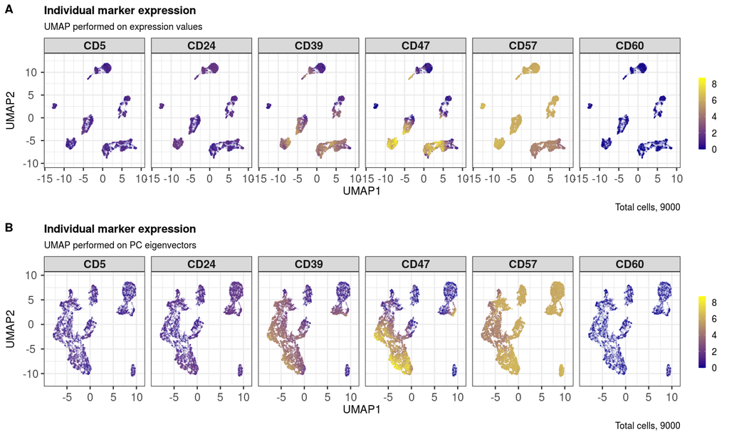

```r
  ggout1 <- markerExpression(sce,
    markers = markers,
    subtitle = 'UMAP performed on expression values',
    nrow = 1, ncol = 6,
    legendKeyHeight = 1.0,
    legendLabSize = 18,
    stripLabSize = 22,
    axisLabSize = 22,
    titleLabSize = 22,
    subtitleLabSize = 18,
    captionLabSize = 18)

  ggout2 <-  markerExpression(sce,
    markers = markers,
    reducedDim = 'UMAP_PCA',
    subtitle = 'UMAP performed on PC eigenvectors',
    nrow = 1, ncol = 6,
    legendKeyHeight = 1.0,
    legendLabSize = 18,
    stripLabSize = 22,
    axisLabSize = 22,
    titleLabSize = 22,
    subtitleLabSize = 18,
    captionLabSize = 18)

  plot_grid(ggout1, ggout2,
    labels = c('A','B'),
    nrow = 2, align = "l", label_size = 24)
```

## Shade cells by metadata

Shading cells by metadata can be useful for identifying any batch effects, but also useful for visualising, e.g., differences across treatments.

First, let's take a look inside the metadata that we have.

```r
  head(metadata(sce))
```

```
##       sample   group treatment
## cell1  HD262 Healthy      CD46
## cell2  HD262 Healthy      CD46
## cell3    P00 Disease      CD46
## cell4  HD262 Healthy      CD46
## cell5   HD01 Healthy    Unstim
## cell6    P00 Disease    Unstim
```

```r
  levels(metadata(sce)$group)
```

```
## [1] "Healthy" "Disease"
```

```r
  levels(metadata(sce)$treatment)
```

```
## [1] "CD46"   "Unstim" "CD3"
```

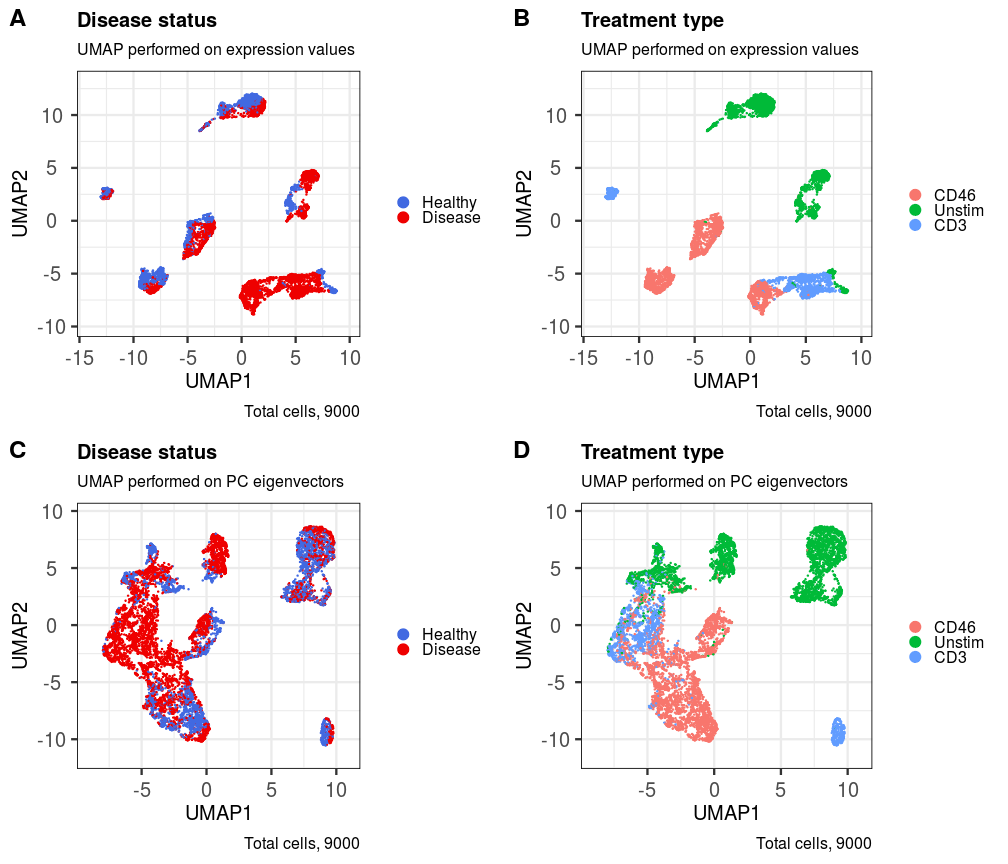

```r
  ggout1 <- metadataPlot(sce,
    colby = 'group',
    colkey = c(Healthy = 'royalblue', Disease = 'red2'),
    title = 'Disease status',
    subtitle = 'UMAP performed on expression values',
    legendLabSize = 16,
    axisLabSize = 20,
    titleLabSize = 20,
    subtitleLabSize = 16,
    captionLabSize = 16)

  ggout2 <- metadataPlot(sce,
    reducedDim = 'UMAP_PCA',
    colby = 'group',
    colkey = c(Healthy = 'royalblue', Disease = 'red2'),
    title = 'Disease status',
    subtitle = 'UMAP performed on PC eigenvectors',
    legendLabSize = 16,
    axisLabSize = 20,
    titleLabSize = 20,
    subtitleLabSize = 16,
    captionLabSize = 16)

  ggout3 <- metadataPlot(sce,
    colby = 'treatment',
    title = 'Treatment type',
    subtitle = 'UMAP performed on expression values',
    legendLabSize = 16,
    axisLabSize = 20,
    titleLabSize = 20,
    subtitleLabSize = 16,
    captionLabSize = 16)

  ggout4 <- metadataPlot(sce,
    reducedDim = 'UMAP_PCA',
    colby = 'treatment',
    title = 'Treatment type',
    subtitle = 'UMAP performed on PC eigenvectors',
    legendLabSize = 16,
    axisLabSize = 20,
    titleLabSize = 20,
    subtitleLabSize = 16,
    captionLabSize = 16)

  plot_grid(ggout1, ggout3, ggout2, ggout4,
    labels = c('A','B','C','D'),
    nrow = 2, ncol = 2, align = "l", label_size = 24)
```

## Find ideal clusters in the UMAP layout via k-nearest neighbours

This function utilises the k nearest neighbours (k-NN) approach from Seurat, which works quite well on flow cytometry and CyTOF UMAP layouts, from my experience.

```r
  sce <- clusKNN(sce,
    k.param = 20,
    prune.SNN = 1/15,
    resolution = 0.01,
    algorithm = 2)
```

```
## Modularity Optimizer version 1.3.0 by Ludo Waltman and Nees Jan van Eck
##
## Number of nodes: 9000
## Number of edges: 193359
##
## Running Louvain algorithm with multilevel refinement...
## Maximum modularity in 10 random starts: 0.9982
## Number of communities: 9
## Elapsed time: 1 seconds
```

```r
  sce <- clusKNN(sce,
    reducedDim = 'UMAP_PCA',
    clusterAssignName = 'Cluster_PCA',
    k.param = 20,
    prune.SNN = 1/15,
    resolution = 0.01,
    algorithm = 2)
```

```
## Modularity Optimizer version 1.3.0 by Ludo Waltman and Nees Jan van Eck
##
## Number of nodes: 9000
## Number of edges: 186603
##
## Running Louvain algorithm with multilevel refinement...
## Maximum modularity in 10 random starts: 0.9970
## Number of communities: 6
## Elapsed time: 0 seconds
```

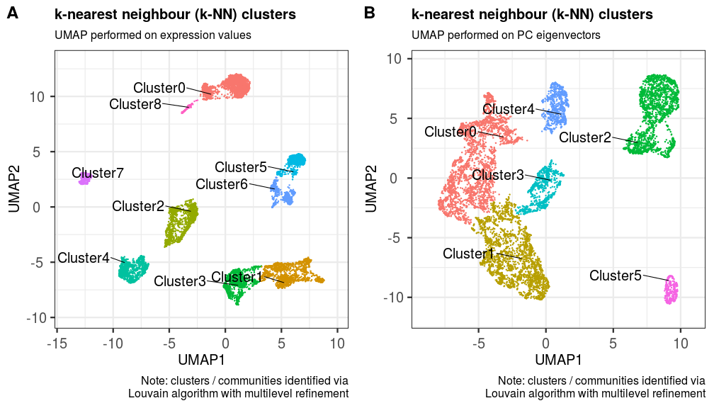

```r
  ggout1 <- plotClusters(sce,
    clusterColname = 'Cluster',
    labSize = 7.0,
    subtitle = 'UMAP performed on expression values',
    caption = paste0('Note: clusters / communities identified via',
      '\nLouvain algorithm with multilevel refinement'),
    axisLabSize = 20,
    titleLabSize = 20,
    subtitleLabSize = 16,
    captionLabSize = 16)

  ggout2 <- plotClusters(sce,
    clusterColname = 'Cluster_PCA',
    reducedDim = 'UMAP_PCA',
    labSize = 7.0,
    subtitle = 'UMAP performed on PC eigenvectors',
    caption = paste0('Note: clusters / communities identified via',
      '\nLouvain algorithm with multilevel refinement'),
    axisLabSize = 20,
    titleLabSize = 20,
    subtitleLabSize = 16,
    captionLabSize = 16)

  plot_grid(ggout1, ggout2,
    labels = c('A','B'),
    ncol = 2, align = "l", label_size = 24)
```

## Plot marker expression per identified cluster

```r
  markerExpressionPerCluster(sce,
    caption = 'Cluster assignments based on UMAP performed on expression values',
    stripLabSize = 22,
    axisLabSize = 22,
    titleLabSize = 22,
    subtitleLabSize = 18,
    captionLabSize = 18)
```

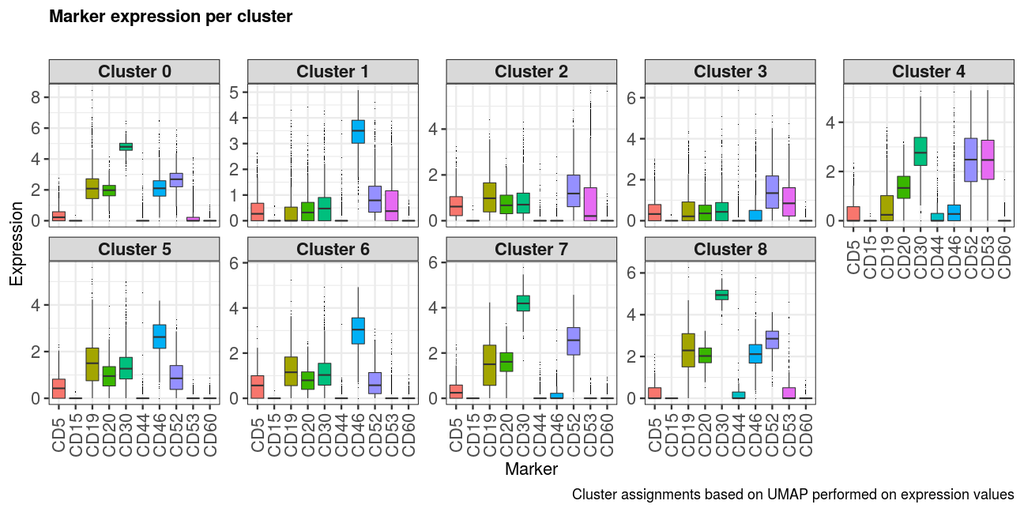

```r
  clusters <- unique(metadata(sce)[['Cluster_PCA']])
  clusters
```

```
## [1] 1 3 0 2 5 4
```

```r
  markers <- sample(rownames(sce), 8)
  markers
```

```
## [1] "CD23" "CD48" "CD39" "CD34" "CD15" "CD58" "CD5"  "CD30"
```

```r
  markerExpressionPerCluster(sce,
    clusters = clusters,
    clusterAssign = metadata(sce)[['Cluster_PCA']],
    markers = markers,
    nrow = 2, ncol = 4,
    caption = 'Cluster assignments based on UMAP performed on PC eigenvectors',
    stripLabSize = 22,
    axisLabSize = 22,
    titleLabSize = 22,
    subtitleLabSize = 18,
    captionLabSize = 18)
```

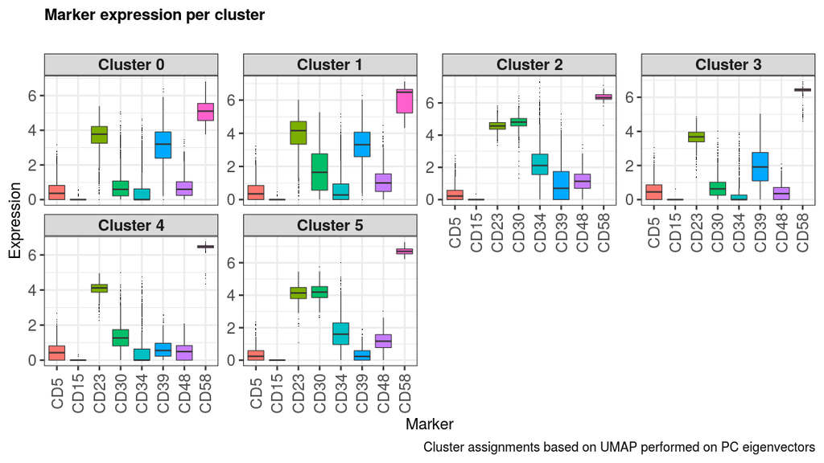

## Determine enriched markers in each cluster and plot the expression signature

This method also calculates metacluster abundances across a chosen phenotype. The function returns a data-frame, which can then be exported to do other analyses.

### Disease vs Healthy metacluster abundances

| Cluster | nCells | TotalCells | PercentCells | NegMarkers | PosMarkers | PerCent_Healthy | PerCent_Disease | nCell_Healthy | nCell_Disease |
| --- | --- | --- | --- | --- | --- | --- | --- | --- | --- |
| 0 | 1798 | 9000 | 19.977778 | NA | NA | 61.790879 | 38.20912 | 1111 | 687 |
| 1 | 1580 | 9000 | 17.555556 | CD47- | CD30+ | 24.050633 | 75.94937 | 380 | 1200 |
| 2 | 1388 | 9000 | 15.422222 | CD30- | CD46+ | 33.429395 | 66.57061 | 464 | 924 |
| 3 | 1196 | 9000 | 13.288889 | CD30-CD37-CD46- | CD51+ | 0.083612 | 99.91639 | 1 | 1195 |
| 4 | 1084 | 9000 | 12.044444 | CD30- | CD47+ | 77.952029 | 22.04797 | 845 | 239 |
| 5 | 766 | 9000 | 8.511111 | CD46- | CD47+CD51+ | 10.835509 | 89.16449 | 83 | 683 |
| 6 | 659 | 9000 | 7.322222 | CD47- | CD31+ | 37.632777 | 62.36722 | 248 | 411 |
| 7 | 329 | 9000 | 3.655556 | CD21-CD47-CD51- | CD46+ | 63.525836 | 36.47416 | 209 | 120 |
| 8 | 200 | 9000 | 2.222222 | CD21-CD47- | CD30+ | 69.000000 | 31.00000 | 138 | 62 |

.

### Treatment type metacluster abundances

| Cluster | nCells | TotalCells | PercentCells | NegMarkers | PosMarkers | PerCent_CD46 | PerCent_Unstim | PerCent_CD3 | nCell_CD46 | nCell_Unstim | nCell_CD3 |
| --- | --- | --- | --- | --- | --- | --- | --- | --- | --- | --- | --- |
| 0 | 1798 | 9000 | 19.977778 | NA | NA | 0.1112347 | 99.8887653 | 0.0000000 | 2 | 1796 | 0 |
| 1 | 1580 | 9000 | 17.555556 | CD47- | CD30+ | 0.5696203 | 24.1139241 | 75.3164557 | 9 | 381 | 1190 |
| 2 | 1388 | 9000 | 15.422222 | CD30- | CD46+ | 99.3515850 | 0.5763689 | 0.0720461 | 1379 | 8 | 1 |
| 3 | 1196 | 9000 | 13.288889 | CD30-CD37-CD46- | CD51+ | 91.3043478 | 0.0000000 | 8.6956522 | 1092 | 0 | 104 |
| 4 | 1084 | 9000 | 12.044444 | CD30- | CD47+ | 100.0000000 | 0.0000000 | 0.0000000 | 1084 | 0 | 0 |
| 5 | 766 | 9000 | 8.511111 | CD46- | CD47+CD51+ | 0.1305483 | 99.8694517 | 0.0000000 | 1 | 765 | 0 |
| 6 | 659 | 9000 | 7.322222 | CD47- | CD31+ | 0.7587253 | 99.2412747 | 0.0000000 | 5 | 654 | 0 |
| 7 | 329 | 9000 | 3.655556 | CD21-CD47-CD51- | CD46+ | 0.0000000 | 0.6079027 | 99.3920973 | 0 | 2 | 327 |
| 8 | 200 | 9000 | 2.222222 | CD21-CD47- | CD30+ | 0.0000000 | 99.5000000 | 0.5000000 | 0 | 199 | 1 |

.

### Expression signature

The expression signature is a quick way to visualise which markers are more or less expressed in each identified cluster of cells.

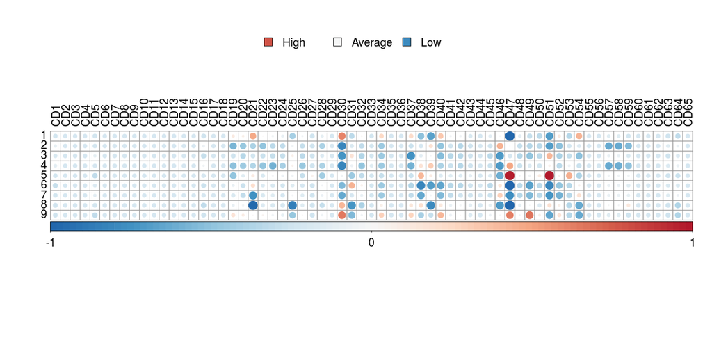

```r
  plotSignatures(sce,
    labCex = 1.5,
    legendCex = 1.5)
```

# Tutorial 2: Import from Seurat

Due to the fact that *scDataviz* is based on *SingleCellExperiment*, it has increased interoperability with other packages, including the popular *Seurat* [@satijalab]. Taking the data produced from the [Seurat Tutorial](https://satijalab.org/seurat/v3.1/pbmc3k_tutorial.html) on Peripheral Blood Mononuclear Cells (PBMCs), we can convert this to a *SingleCellExperiment* object recognisable by *scDataviz* via `as.SingleCellExperiment()`.

For a full workflow for *Seurat*-to-*scDataviz*, see the [GitHub vignette](https://github.com/kevinblighe/scDataviz/).

# Tutorial 3: Import any numerical data

*scDataviz* will work with any numerical data, too. Here, we show a quick example of how one can import a data-matrix of randomly-generated numbers that follow a negative binomial distribution, comprising 2500 cells and 20 markers:

```r
  mat <- jitter(matrix(
    MASS::rnegbin(rexp(50000, rate=.1), theta = 4.5),
    ncol = 20))
  colnames(mat) <- paste0('CD', 1:ncol(mat))
  rownames(mat) <- paste0('cell', 1:nrow(mat))

  metadata <- data.frame(
    group = rep('A', nrow(mat)),
    row.names = rownames(mat),
    stringsAsFactors = FALSE)
  head(metadata)
```

```
##       group
## cell1     A
## cell2     A
## cell3     A
## cell4     A
## cell5     A
## cell6     A
```

```r
  sce <- importData(mat,
    assayname = 'normcounts',
    metadata = metadata)
  sce
```

```
## class: SingleCellExperiment
## dim: 20 2500
## metadata(1): group
## assays(1): normcounts
## rownames(20): CD1 CD2 ... CD19 CD20
## rowData names(0):
## colnames(2500): cell1 cell2 ... cell2499 cell2500
## colData names(0):
## reducedDimNames(0):
## spikeNames(0):
## altExpNames(0):
```

This will also work without any assigned metadata.

```r
  sce <- importData(mat,
    assayname = 'normcounts',
    metadata = NULL)
  sce
```

```
## class: SingleCellExperiment
## dim: 20 2500
## metadata(0):
## assays(1): normcounts
## rownames(20): CD1 CD2 ... CD19 CD20
## rowData names(0):
## colnames(2500): cell1 cell2 ... cell2499 cell2500
## colData names(0):
## reducedDimNames(0):
## spikeNames(0):
## altExpNames(0):
```

# Acknowledgments

- Jessica Timms
- James Opzoomer

# References

@scDataviz

@Lun

@Wickham

@PCAtools

@satijalab